# Alimentação Escolar: Amazônia Legal vs Restante do Brasil

Análise Comparativa - Censo Escolar 2025 e SIOPE 2024

# Panorama Geral da Alimentação Escolar

Panorama da alimentação escolar - Censo Escolar 2025 (escolas públicas da Ed. Básica)

| Indicador | Amazônia Legal | Restante do Brasil |
| --- | --- | --- |
| **Escolas e alunos** |  |  |
| Total de escolas públicas (Ed. Básica) | 30.192 | 104.042 |
| Total de alunos matriculados | 6.211.371 | 29.964.589 |
| **Infraestrutura de alimentação** |  |  |
| Escolas com alimentação escolar | 30.146 (99,8%) | 103.829 (99,8%) |
| Escolas com cozinha | 28.107 (93,1%) | 102.608 (98,6%) |
| Escolas com despensa | 18.863 (62,5%) | 83.420 (80,2%) |
| Escolas com refeitório | 11.596 (38,4%) | 64.359 (61,9%) |
| Escolas com água potável | 25.840 (85,6%) | 102.678 (98,7%) |
| Escolas sem abastecimento de água | 1.043 (3,5%) | 148 (0,1%) |
| Escolas com área de plantio/horta | 2.645 (8,8%) | 15.626 (15,0%) |
| **Profissionais** |  |  |
| Nutricionistas | 2.313.509 | 2.076.707 |
| Profissionais de alimentação (merendeiras) | 2.013.793 | 6.754.493 |
| Alunos por nutricionista | 3 | 14 |
| Alunos por profissional de alimentação | 3 | 4 |

# Infraestrutura de Alimentação

## Por Localização (Urbana/Rural)

Infraestrutura de alimentação por localização - Censo Escolar 2025

| Localização | Região | Escolas | Cozinha | Refeitório | Água potável | Sem água |
| --- | --- | --- | --- | --- | --- | --- |
| Rural | Amazônia Legal | 19.293 | **89.8%** | **24.5%** | **78.7%** | **5.2%** |
| Rural | Restante do Brasil | 29.909 | **98.0%** | **36.8%** | **96.6%** | **0.5%** |
| Urbana | Amazônia Legal | 10.899 | **98.9%** | **63.0%** | **97.9%** | **0.4%** |
| Urbana | Restante do Brasil | 74.133 | **98.9%** | **72.0%** | **99.5%** | **0.0%** |

A análise por localização revela que as escolas rurais da Amazônia Legal enfrentam as condições mais precárias: apenas 24.5% possuem refeitório (contra 36.8% no Restante do Brasil rural) e 5.2% não possuem abastecimento de água (contra 0.5% no Restante do Brasil rural). No meio urbano, as diferenças são menores, com 63.0% de escolas com refeitório na Amazônia Legal e 72.0% no Restante do Brasil. A ausência de água potável é especialmente grave no contexto da preparação de refeições escolares, pois compromete tanto a segurança alimentar quanto as condições sanitárias de manipulação dos alimentos.

## Por Localização Diferenciada

Infraestrutura de alimentação em escolas de localização diferenciada - Censo Escolar 2025

| Localização | Região | Escolas | Com alimentação | Cozinha | Refeitório | Sem água |
| --- | --- | --- | --- | --- | --- | --- |
| Comunidade remanescente de quilombos | Amazônia Legal | 1.128 | **99.9%** | **98.0%** | **16.5%** | **6.0%** |
| Comunidade remanescente de quilombos | Restante do Brasil | 1.544 | **100.0%** | **98.4%** | **32.6%** | **0.6%** |
| Outro | Amazônia Legal | 1.124 | **100.0%** | **89.9%** | **31.8%** | **5.8%** |
| Outro | Restante do Brasil | 329 | **99.7%** | **99.1%** | **52.6%** | **0.3%** |
| Terra indígena | Amazônia Legal | 2.939 | **99.9%** | **64.2%** | **14.6%** | **8.6%** |
| Terra indígena | Restante do Brasil | 758 | **99.7%** | **93.8%** | **28.4%** | **1.3%** |
| Área de assentamento | Amazônia Legal | 2.940 | **99.9%** | **95.8%** | **24.9%** | **5.2%** |
| Área de assentamento | Restante do Brasil | 1.505 | **99.9%** | **96.7%** | **31.3%** | **0.6%** |

As escolas em localizações diferenciadas (assentamentos, terras indígenas, comunidades quilombolas e ribeirinhas) apresentam, em geral, condições de infraestrutura de alimentação ainda mais precárias que as escolas rurais convencionais. Essas comunidades, majoritariamente concentradas na Amazônia Legal, enfrentam desafios logísticos adicionais para o abastecimento de alimentos e insumos, elevando o custo efetivo por refeição servida. A alta proporção de escolas sem abastecimento de água nessas localidades é particularmente alarmante, pois impacta diretamente a segurança sanitária das refeições e a saúde dos estudantes.

## Infraestrutura por UF

Infraestrutura de alimentação escolar por UF - Censo Escolar 2025

| UF | Região | Escolas | Alimentação | Cozinha | Refeitório | Sem água |
| --- | --- | --- | --- | --- | --- | --- |
| RJ | Restante do Brasil | 6.653 | **99.7%** | **98.9%** | **93.6%** | **0.0%** |
| ES | Restante do Brasil | 2.607 | **99.3%** | **99.5%** | **88.0%** | **0.2%** |
| MG | Restante do Brasil | 11.795 | **99.8%** | **99.6%** | **86.8%** | **0.0%** |
| RS | Restante do Brasil | 7.066 | **99.7%** | **98.9%** | **86.2%** | **0.1%** |
| SC | Restante do Brasil | 4.896 | **99.9%** | **98.8%** | **85.4%** | **0.0%** |
| MT | Amazônia Legal | 2.208 | **99.5%** | **98.6%** | **80.8%** | **0.5%** |
| SP | Restante do Brasil | 18.487 | **99.7%** | **98.7%** | **74.6%** | **0.0%** |
| PR | Restante do Brasil | 7.277 | **99.8%** | **99.3%** | **69.7%** | **0.0%** |
| AP | Amazônia Legal | 766 | **99.6%** | **95.2%** | **66.7%** | **2.1%** |
| RO | Amazônia Legal | 990 | **99.4%** | **96.6%** | **65.3%** | **1.4%** |
| MS | Restante do Brasil | 1.356 | **99.7%** | **99.6%** | **60.0%** | **0.0%** |
| RN | Restante do Brasil | 2.624 | **100.0%** | **99.0%** | **47.2%** | **0.0%** |
| AL | Restante do Brasil | 2.324 | **99.8%** | **99.4%** | **45.8%** | **0.0%** |
| PB | Restante do Brasil | 3.610 | **99.9%** | **96.0%** | **43.3%** | **0.4%** |
| PA | Amazônia Legal | 9.548 | **99.9%** | **96.7%** | **42.5%** | **3.5%** |
| AC | Amazônia Legal | 1.466 | **100.0%** | **90.6%** | **42.3%** | **18.4%** |
| GO | Restante do Brasil | 3.473 | **99.7%** | **99.8%** | **41.6%** | **0.0%** |
| AM | Amazônia Legal | 5.052 | **99.9%** | **83.2%** | **40.3%** | **0.8%** |
| CE | Restante do Brasil | 5.802 | **100.0%** | **99.3%** | **39.6%** | **0.0%** |
| DF | Restante do Brasil | 668 | **98.4%** | **99.1%** | **35.9%** | **0.0%** |
| RR | Amazônia Legal | 852 | **99.9%** | **77.9%** | **35.3%** | **1.3%** |
| SE | Restante do Brasil | 1.502 | **99.4%** | **99.4%** | **34.0%** | **0.1%** |
| PE | Restante do Brasil | 5.801 | **99.8%** | **98.7%** | **33.4%** | **0.3%** |
| PI | Restante do Brasil | 3.388 | **100.0%** | **96.8%** | **32.8%** | **0.6%** |
| BA | Restante do Brasil | 12.770 | **99.9%** | **97.1%** | **30.9%** | **0.4%** |
| TO | Amazônia Legal | 1.372 | **99.9%** | **99.2%** | **26.7%** | **0.0%** |
| MA | Amazônia Legal | 9.881 | **99.8%** | **94.5%** | **16.0%** | **3.8%** |

# Despesas com Alimentação Escolar (SIOPE)

## Despesa Agregada por Região

Despesas com Alimentação Escolar (subfunção 306) - SIOPE 2024

| Indicador | Amazônia Legal | Restante do Brasil |
| --- | --- | --- |
| **Volumes totais** |  |  |
| Municípios declarantes | 676 | 4.583 |
| Despesa empenhada total | R$ 1,10 bi | R$ 9,39 bi |
| Despesa paga total | R$ 1,04 bi | R$ 8,78 bi |
| **Indicadores comparativos** |  |  |
| Taxa de execução (liq/emp) | **97.6%** | **96.7%** |
| Despesa per capita | **R$ 40,40** | **R$ 50,99** |
| Despesa por aluno matriculado | **R$ 168,11** | **R$ 293,04** |
| % Alimentação / Despesa educacional total | **1.6%** | **2.3%** |

## Despesa por Aluno por UF

Despesa com Alimentação Escolar por aluno por UF - SIOPE 2024

| UF | Região | Alunos (Ed. Básica) | Despesa total | Despesa por aluno |
| --- | --- | --- | --- | --- |
| SP | Restante do Brasil | 6.971.715 | R$ 3.339,3 mi | **R$ 478,98** |
| SC | Restante do Brasil | 1.412.779 | R$ 520,2 mi | **R$ 368,22** |
| PE | Restante do Brasil | 1.562.926 | R$ 533,0 mi | **R$ 341,04** |
| RJ | Restante do Brasil | 2.226.734 | R$ 632,8 mi | **R$ 284,18** |
| MT | Amazônia Legal | 775.208 | R$ 217,4 mi | **R$ 280,38** |
| PR | Restante do Brasil | 1.924.636 | R$ 520,3 mi | **R$ 270,35** |
| MS | Restante do Brasil | 564.109 | R$ 152,2 mi | **R$ 269,80** |
| BA | Restante do Brasil | 2.765.910 | R$ 674,1 mi | **R$ 243,73** |
| TO | Amazônia Legal | 337.845 | R$ 81,6 mi | **R$ 241,39** |
| MG | Restante do Brasil | 3.430.222 | R$ 786,7 mi | **R$ 229,35** |
| GO | Restante do Brasil | 1.226.080 | R$ 266,9 mi | **R$ 217,70** |
| RS | Restante do Brasil | 1.681.038 | R$ 348,9 mi | **R$ 207,53** |
| ES | Restante do Brasil | 735.315 | R$ 147,2 mi | **R$ 200,18** |
| CE | Restante do Brasil | 1.636.764 | R$ 317,3 mi | **R$ 193,85** |
| PB | Restante do Brasil | 737.516 | R$ 139,5 mi | **R$ 189,12** |
| PA | Amazônia Legal | 1.912.631 | R$ 355,0 mi | **R$ 185,59** |
| SE | Restante do Brasil | 402.535 | R$ 74,1 mi | **R$ 183,97** |
| AL | Restante do Brasil | 706.387 | R$ 115,5 mi | **R$ 163,52** |
| PI | Restante do Brasil | 689.781 | R$ 111,4 mi | **R$ 161,49** |
| AM | Amazônia Legal | 1.021.612 | R$ 142,2 mi | **R$ 139,24** |
| MA | Amazônia Legal | 1.566.017 | R$ 197,2 mi | **R$ 125,95** |
| RN | Restante do Brasil | 580.916 | R$ 68,8 mi | **R$ 118,37** |
| RO | Amazônia Legal | 324.349 | R$ 35,9 mi | **R$ 110,77** |
| AC | Amazônia Legal | 226.438 | R$ 20,4 mi | **R$ 90,31** |
| AP | Amazônia Legal | 185.411 | R$ 15,0 mi | **R$ 80,88** |
| RR | Amazônia Legal | 168.732 | R$ 12,3 mi | **R$ 73,00** |

A despesa por aluno com alimentação escolar varia substancialmente entre as UFs. Na Amazônia Legal, **MT** apresenta a maior despesa por aluno (R$ 280,38) e **RR** a menor (R$ 73,00). A mediana entre os estados amazônicos (R$ 125,95) é inferior à mediana do Restante do Brasil (R$ 217,70). A variabilidade interna na Amazônia Legal reflete diferenças na capacidade fiscal de cada estado, no custo de transporte de alimentos até as escolas e nos programas complementares de alimentação adotados localmente.

## Despesa Municipal por Aluno (Distribuição)

Distribuição da despesa municipal por aluno com alimentação escolar - SIOPE 2024

| Região | Municípios | 1o quartil | Mediana | Média | 3o quartil |
| --- | --- | --- | --- | --- | --- |
| Amazônia Legal | 676 | **R$ 112,89** | **R$ 185,57** | **R$ 225,02** | **R$ 279,37** |
| Restante do Brasil | 4.583 | **R$ 123,66** | **R$ 236,55** | **R$ 367,94** | **R$ 447,87** |

A distribuição municipal da despesa por aluno com alimentação escolar mostra que a mediana na Amazônia Legal é de R$ 185,57 por aluno, contra R$ 236,55 no Restante do Brasil. No 1o quartil (25% dos municípios com menor gasto), a Amazônia Legal investe R$ 112,89 contra R$ 123,66 no Restante do Brasil. No 3o quartil, os valores são R$ 279,37 (Amazônia Legal) e R$ 447,87 (Restante do Brasil). A amplitude interquartil indica que a desigualdade no financiamento da alimentação escolar não se restringe ao gap entre macrorregiões, mas se manifesta também na variabilidade entre municípios dentro de cada região.

# Profissionais de Alimentação

## Nutricionistas por UF

Profissionais de alimentação escolar por UF - Censo Escolar 2025

| UF | Região | Nutricionistas | Merendeiras | % escolas c/ merendeira | Alunos por merendeira |
| --- | --- | --- | --- | --- | --- |
| DF | Restante do Brasil | 7 | 2.262 | **90.7%** | **178** |
| ES | Restante do Brasil | 511 | 6.008 | **86.4%** | **122** |
| MS | Restante do Brasil | 447 | 5.115 | **94.4%** | **110** |
| MT | Amazônia Legal | 156 | 7.290 | **90.5%** | **106** |
| PR | Restante do Brasil | 1.999 | 18.254 | **96.2%** | **105** |
| RO | Amazônia Legal | 66 | 3.307 | **87.9%** | **98** |
| AL | Restante do Brasil | 1.423.128 | 8.092 | **94.0%** | **87** |
| AP | Amazônia Legal | 49 | 2.146 | **88.1%** | **86** |
| CE | Restante do Brasil | 961 | 101.911 | **89.9%** | **16** |
| GO | Restante do Brasil | 585 | 100.140 | **91.6%** | **12** |
| AM | Amazônia Legal | 577 | 96.087 | **59.2%** | **11** |
| SP | Restante do Brasil | 5.489 | 842.942 | **83.4%** | **8** |
| PE | Restante do Brasil | 1.330 | 191.773 | **87.3%** | **8** |
| RJ | Restante do Brasil | 1.474 | 286.166 | **88.0%** | **8** |
| SC | Restante do Brasil | 448.760 | 189.464 | **94.5%** | **7** |
| RS | Restante do Brasil | 1.561 | 282.152 | **92.5%** | **6** |
| BA | Restante do Brasil | 3.939 | 564.769 | **85.0%** | **5** |
| SE | Restante do Brasil | 51 | 93.238 | **90.7%** | **4** |
| TO | Amazônia Legal | 100 | 93.677 | **96.8%** | **4** |
| PB | Restante do Brasil | 1.125 | 273.994 | **86.0%** | **3** |
| PI | Restante do Brasil | 179.437 | 273.764 | **80.9%** | **3** |
| AC | Amazônia Legal | 197 | 91.035 | **60.8%** | **2** |
| MA | Amazônia Legal | 2.311.955 | 636.620 | **61.0%** | **2** |
| RN | Restante do Brasil | 615 | 273.554 | **91.3%** | **2** |
| PA | Amazônia Legal | 488 | 1.174.043 | **70.2%** | **2** |
| MG | Restante do Brasil | 5.181 | 2.793.191 | **87.0%** | **1** |
| RR | Amazônia Legal | 28 | 357.292 | **81.5%** | **0** |

## Profissionais por Localização

Profissionais de alimentação por localização - Censo Escolar 2025

| Localização | Região | Escolas | Merendeiras | % escolas c/ merendeira | Alunos por merendeira |
| --- | --- | --- | --- | --- | --- |
| Rural | Amazônia Legal | 19.293 | 1.534.666 | **61.2%** | **1** |
| Rural | Restante do Brasil | 29.909 | 3.428.716 | **83.7%** | **1** |
| Urbana | Amazônia Legal | 10.899 | 479.127 | **83.3%** | **9** |
| Urbana | Restante do Brasil | 74.133 | 3.325.777 | **89.3%** | **8** |

A análise por localização mostra que as escolas rurais da Amazônia Legal apresentam 61.2% de cobertura com merendeiras, com razão de 1 alunos por profissional. No Restante do Brasil rural, a cobertura é de 83.7% com 1 alunos por merendeira. A menor cobertura de profissionais nas escolas rurais amazônicas é especialmente preocupante, pois essas escolas frequentemente não dispõem de alternativas para o preparo local das refeições, e a distância até centros urbanos inviabiliza soluções de alimentação terceirizada.

# Custo por Aluno e Infraestrutura Integrada

Visão integrada: despesa por aluno, infraestrutura e profissionais - SIOPE 2024 + Censo 2025

| UF | Região | R$ por aluno | Cozinha | Refeitório | Alunos/merendeira |
| --- | --- | --- | --- | --- | --- |
| SP | Restante do Brasil | **R$ 478,98** | **98.7%** | **74.6%** | **8** |
| SC | Restante do Brasil | **R$ 368,22** | **98.8%** | **85.4%** | **7** |
| PE | Restante do Brasil | **R$ 341,04** | **98.7%** | **33.4%** | **8** |
| RJ | Restante do Brasil | **R$ 284,18** | **98.9%** | **93.6%** | **8** |
| MT | Amazônia Legal | **R$ 280,38** | **98.6%** | **80.8%** | **106** |
| PR | Restante do Brasil | **R$ 270,35** | **99.3%** | **69.7%** | **105** |
| MS | Restante do Brasil | **R$ 269,80** | **99.6%** | **60.0%** | **110** |
| BA | Restante do Brasil | **R$ 243,73** | **97.1%** | **30.9%** | **5** |
| TO | Amazônia Legal | **R$ 241,39** | **99.2%** | **26.7%** | **4** |
| MG | Restante do Brasil | **R$ 229,35** | **99.6%** | **86.8%** | **1** |
| GO | Restante do Brasil | **R$ 217,70** | **99.8%** | **41.6%** | **12** |
| RS | Restante do Brasil | **R$ 207,53** | **98.9%** | **86.2%** | **6** |
| ES | Restante do Brasil | **R$ 200,18** | **99.5%** | **88.0%** | **122** |
| CE | Restante do Brasil | **R$ 193,85** | **99.3%** | **39.6%** | **16** |
| PB | Restante do Brasil | **R$ 189,12** | **96.0%** | **43.3%** | **3** |
| PA | Amazônia Legal | **R$ 185,59** | **96.7%** | **42.5%** | **2** |
| SE | Restante do Brasil | **R$ 183,97** | **99.4%** | **34.0%** | **4** |
| AL | Restante do Brasil | **R$ 163,52** | **99.4%** | **45.8%** | **87** |
| PI | Restante do Brasil | **R$ 161,49** | **96.8%** | **32.8%** | **3** |
| AM | Amazônia Legal | **R$ 139,24** | **83.2%** | **40.3%** | **11** |
| MA | Amazônia Legal | **R$ 125,95** | **94.5%** | **16.0%** | **2** |
| RN | Restante do Brasil | **R$ 118,37** | **99.0%** | **47.2%** | **2** |
| RO | Amazônia Legal | **R$ 110,77** | **96.6%** | **65.3%** | **98** |
| AC | Amazônia Legal | **R$ 90,31** | **90.6%** | **42.3%** | **2** |
| AP | Amazônia Legal | **R$ 80,88** | **95.2%** | **66.7%** | **86** |
| RR | Amazônia Legal | **R$ 73,00** | **77.9%** | **35.3%** | **0** |

A tabela integrada permite visualizar simultaneamente o investimento por aluno em alimentação escolar, a infraestrutura disponível nas escolas e a disponibilidade de profissionais. Os estados que combinam baixa despesa por aluno com precária infraestrutura de cozinha/refeitório e poucos profissionais de alimentação são os que demandam atenção prioritária nas políticas de alimentação escolar. Na Amazônia Legal, observa-se que vários estados acumulam desvantagens em todas as dimensões analisadas, configurando um cenário de múltipla privação que afeta diretamente a qualidade nutricional das refeições oferecidas aos estudantes.

# Gráficos Comparativos

## Despesa por Aluno por Região

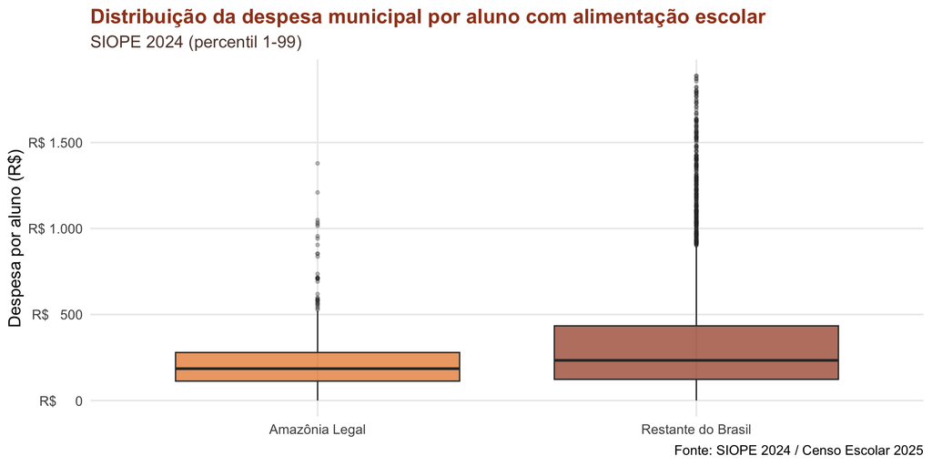

## Infraestrutura Comparada

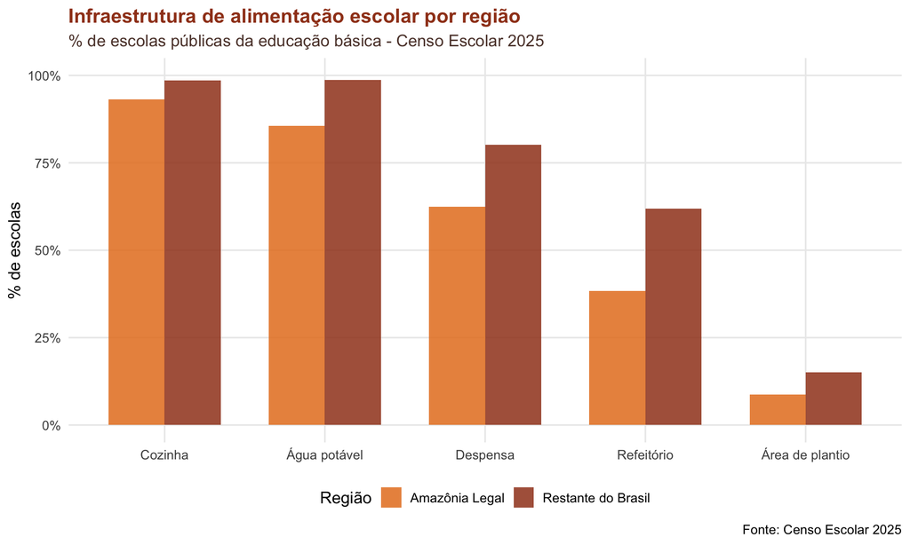

## Despesa por Aluno por UF

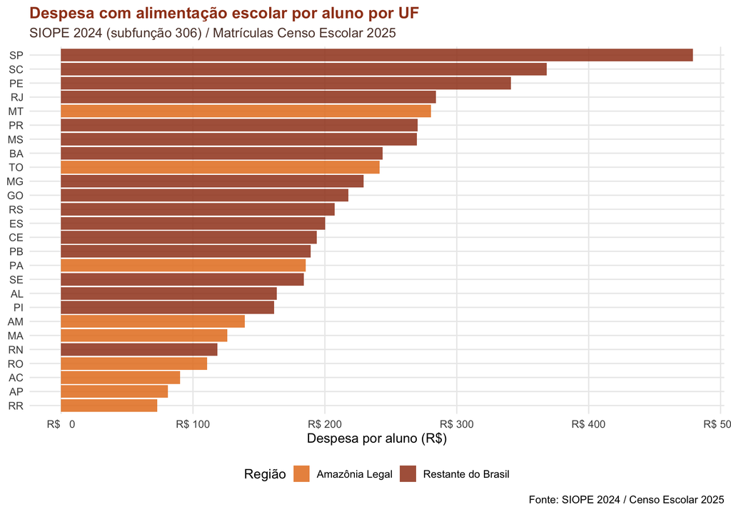

# Síntese Comparativa

Síntese comparativa da alimentação escolar - Censo 2025 + SIOPE 2024

| Indicador | Amazônia Legal | Restante do Brasil | Diferença |
| --- | --- | --- | --- |
| **Infraestrutura (Censo Escolar 2025)** |  |  |  |
| Escolas com alimentação (%) | **99.8%** | **99.8%** | ● 0.1 p.p. |
| Escolas com cozinha (%) | **93.1%** | **98.6%** | ▼ 5.5 p.p. |
| Escolas com refeitório (%) | **38.4%** | **61.9%** | ▼ 23.5 p.p. |
| Escolas com água potável (%) | **85.6%** | **98.7%** | ▼ 13.1 p.p. |
| Escolas sem água (%) | **3.5%** | **0.1%** | ▲ 3.3 p.p. |
| **Despesas (SIOPE 2024)** |  |  |  |
| Despesa per capita | **R$ 40,40** | **R$ 50,99** | ▼ R$ 10,60 |
| Despesa por aluno | **R$ 168,11** | **R$ 293,04** | ▼ R$ 124,93 |
| Mediana municipal por aluno | **R$ 185,57** | **R$ 236,55** | ▼ R$ 50,98 |
| % alimentação no orçamento educacional | **1.6%** | **2.3%** | ▼ 0.7 p.p. |
| **Profissionais (Censo Escolar 2025)** |  |  |  |
| Alunos por merendeira | **3** | **4** | ▼ 1.4 |

# Metodologia

Este relatório integra duas fontes de dados complementares para analisar a alimentação escolar:

Fontes de dados utilizadas

| Fonte | Ano | Variáveis principais |
| --- | --- | --- |
| Censo Escolar 2025 - Tabela de Escolas | 2025 | Infraestrutura (cozinha, refeitório, água), profissionais (nutricionista, merendeira), localização, dependência administrativa |
| Censo Escolar 2025 - Tabela de Matrículas | 2025 | Matrículas por etapa de ensino (Ed. Infantil, Fundamental, Médio, EJA) |
| SIOPE 2024 - Despesas por Função da Educação | 2024 | Despesas empenhadas, liquidadas e pagas na subfunção 306 (Alimentação e Nutrição) |
| SIOPE 2024 - Dados Gerais | 2024 | Receita realizada, população declarada por município |
| Classificação Amazônia Legal (IBGE) | – | Lista dos 772 municípios da Amazônia Legal em 9 UFs |

## Pré-processamento e Limpeza dos Dados

A leitura dos microdados do Censo Escolar 2025 é feita com `fread()` do pacote data.table. Os arquivos CSV do Censo utilizam separador ponto-e-vírgula (;) e codificação Latin-1, enquanto os arquivos SIOPE utilizam UTF-8. Para cada fonte, aplica-se a codificação correta no parâmetro `encoding`. O parâmetro `select` é utilizado para importar apenas as colunas necessárias, reduzindo o consumo de memória.

Na tabela de Escolas (Tabela_Escola_2025.csv), são importadas 22 colunas: CO_ENTIDADE (código único da escola), SG_UF (sigla da UF), CO_MUNICIPIO (código IBGE de 7 dígitos), TP_DEPENDENCIA (1=Federal, 2=Estadual, 3=Municipal, 4=Privada), TP_LOCALIZACAO (1=Urbana, 2=Rural), TP_LOCALIZACAO_DIFERENCIADA (0=Não se aplica, 1=Assentamento, 2=Terra indígena, 3=Quilombo, 4=Uso sustentável, 5=Ribeirinha), TP_SITUACAO_FUNCIONAMENTO, variáveis de infraestrutura hídrica (IN_AGUA_POTAVEL, IN_AGUA_REDE_PUBLICA, IN_AGUA_INEXISTENTE), variáveis de infraestrutura de alimentação (IN_COZINHA, IN_DESPENSA, IN_REFEITORIO, IN_AREA_PLANTIO), variáveis de profissionais (QT_PROF_NUTRICIONISTA, QT_PROF_ALIMENTACAO), indicador de oferta de alimentação (IN_ALIMENTACAO) e indicadores de oferta de etapas (IN_COMUM_CRECHE, IN_COMUM_PRE, IN_COMUM_FUND_AI, IN_COMUM_FUND_AF, IN_COMUM_MEDIO_MEDIO, IN_COMUM_MEDIO_INTEGRADO). Todas as variáveis IN_ são binárias (0 ou 1) e as QT_ são inteiros.

O primeiro filtro aplicado seleciona apenas escolas em atividade (TP_SITUACAO_FUNCIONAMENTO = 1), excluindo escolas extintas, paralisadas ou em processo de encerramento. Em seguida, cria-se um indicador derivado TEM_BASICA, que é TRUE quando a escola oferece ao menos uma etapa da educação básica (creche, pré-escola, fundamental anos iniciais ou finais, médio ou médio integrado). As análises subsequentes filtram apenas escolas públicas da educação básica (TP_DEPENDENCIA entre 1 e 3, e TEM_BASICA == TRUE), excluindo escolas privadas e aquelas que oferecem exclusivamente educação profissional ou superior.

A classificação por localização diferenciada é recodificada de código numérico para texto descritivo via `fcase()`: assentamento, terra indígena, quilombo, comunidade ribeirinha, uso sustentável ou “Não se aplica”. A dependência administrativa também é recodificada (Federal, Estadual, Municipal, Privada) e a localização simplificada em Urbana/Rural.

Na tabela de Matrículas (Tabela_Matricula_2025.csv), importam-se as colunas CO_ENTIDADE e contagens de matrícula por etapa (QT_MAT_BAS para educação básica total, QT_MAT_INF para infantil, QT_MAT_INF_CRE para creche, QT_MAT_INF_PRE para pré-escola, QT_MAT_FUND para fundamental, QT_MAT_FUND_AI e QT_MAT_FUND_AF para anos iniciais e finais, QT_MAT_MED para médio e QT_MAT_EJA para EJA). A junção com a tabela de escolas é feita por CO_ENTIDADE, e valores ausentes de QT_MAT_BAS são substituídos por zero.

A classificação dos municípios da Amazônia Legal segue a lista oficial do IBGE (772 municípios em 9 UFs: AC, AM, AP, MA, MT, PA, RO, RR, TO), contida no arquivo municipios_amazonia_legal.csv. Para compatibilidade com o SIOPE (que usa código de 6 dígitos), cria-se COD_MUNI_6 truncando os 6 primeiros dígitos do código IBGE. A junção entre Censo Escolar e SIOPE utiliza o campo CO_MUNICIPIO do Censo (7 dígitos) diretamente para a classificação regional das escolas, e COD_MUNI_6 para a junção com dados financeiros do SIOPE.

Nos dados do SIOPE, as colunas financeiras (VAL_DESP_PAGA, VAL_DESP_EMPE, VAL_DESP_LIQU) são convertidas de formato texto brasileiro para numérico pela função `siope_num()`. A população (NUM_POPU) e o código do município (COD_MUNI) são convertidos para inteiro. Seleciona-se o 6º bimestre (NUM_PERI = 6) como referência anual acumulada, e filtra-se TIPO = “Municipal” para dados municipais.

## Tratamentos Específicos

As despesas com alimentação escolar são extraídas da base de Despesas por Função da Educação, filtrando a subfunção 306 (Alimentação e Nutrição), que corresponde à classificação funcional do orçamento público para gastos com merenda escolar, incluindo aquisição de gêneros alimentícios, pagamento de merendeiras e serviços terceirizados de alimentação. São consideradas as despesas pagas (NOM_COLU implícito no campo VAL_DESP_PAGA), que representam os recursos efetivamente transferidos do caixa.

O indicador de despesa por aluno em alimentação é calculado dividindo a despesa paga total com subfunção 306 pelo número total de matrículas na educação básica pública (QT_MAT_BAS), agregadas por município ou por região conforme a análise. A despesa per capita (por habitante) utiliza a população declarada no SIOPE (NUM_POPU), obtida da base de Dados Gerais.

A participação da alimentação no total de despesas educacionais é calculada somando as despesas da subfunção 306 por região e dividindo pelo total de despesas da Função 12 (todas as subfunções educacionais), utilizando a base completa de despesas por função carregada para contextualização.

Os indicadores de infraestrutura de alimentação (percentual de escolas com cozinha, despensa, refeitório, água potável, área de plantio) são calculados pela razão entre o número de escolas com o respectivo indicador igual a 1 e o total de escolas públicas da educação básica em cada região. Os indicadores de profissionais (alunos por nutricionista, alunos por profissional de alimentação) dividem o total de alunos pelo total de profissionais de cada categoria por região, usando `pmax(total, 1)` para evitar divisão por zero.

Para as análises por localização diferenciada (terra indígena, quilombo, ribeirinha, assentamento), as escolas são agrupadas pela variável TP_LOCALIZACAO_DIFERENCIADA e os indicadores são recalculados para cada subgrupo, permitindo identificar desigualdades internas à Amazônia Legal.

## Limitações

A defasagem temporal entre o Censo Escolar (2025) e o SIOPE (2024) implica que as matrículas e a infraestrutura escolar são do ano seguinte ao dos dados financeiros. Essa discrepância é considerada aceitável para fins de comparação regional, pois as variações ano a ano são marginais.

As variáveis de infraestrutura do Censo Escolar são autodeclaratórias, preenchidas pelo responsável da escola, e podem não refletir com precisão a real condição dos equipamentos (uma cozinha pode existir mas estar inoperante, por exemplo). Os dados de profissionais (nutricionistas e merendeiras) referem-se ao quadro declarado, que pode divergir do efetivamente em exercício.

O indicador de despesa por aluno em alimentação é uma média agregada que não diferencia o custo real da refeição por localização ou etapa de ensino. Escolas rurais e ribeirinhas na Amazônia Legal enfrentam custos logísticos significativamente maiores para receber gêneros alimentícios, mas esse sobrecusto não é diretamente mensurável com os dados disponíveis.